# Tugas Pertemuan 6

Kholishotur Rofi’ah

2026-09-24

## Packages

```r
library(readxl)
```

```r
library(ggplot2)
library(tsibble)
library(tseries)
library(MASS)
library(forecast)
library(TSA)
library(TTR)
library(aTSA)
library(graphics)
```

## Data Real

Digunakan data jumlah penumpang monorail yang dalam hal ini hanya digunakan data 100 periode awal

```r
data <- read_excel("C:\\Users\\ASUS\\OneDrive\\Dokumen\\Data Kelompok MPDW.xlsx")
data <- data[1:100,]
data.ts <- ts(data$rail_monorail)
```

### Eksplorasi Data

#### Plot Data Penuh

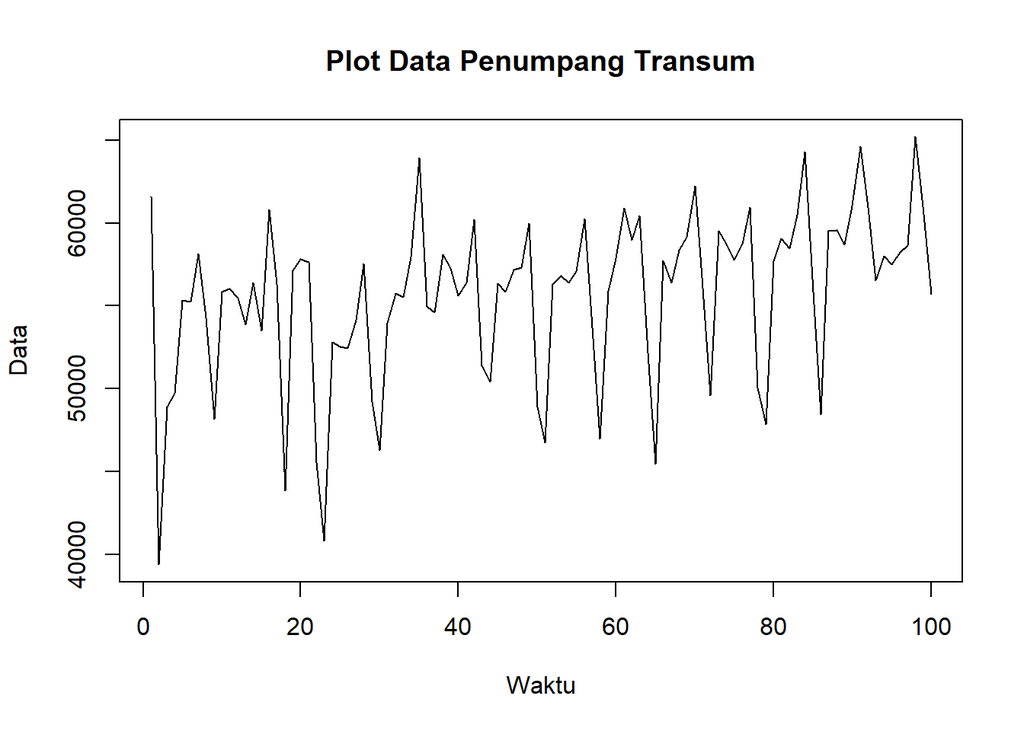

```r
plot.ts(data.ts,
        lty = 1,
        xlab = "Waktu",
        ylab = "Data",
        main = "Plot Data Penumpang Transum")
```

Berdasarkan plot data deret waktu, terlihat bahwa data berfluktuasi di sekitar nilai tengah tertentu dengan pola penurunan tajam yang berulang kira-kira setiap 7 periode, sehingga data diduga memiliki pola musiman mingguan. Oleh karena itu, pembagian data latih dan data uji ditetapkan dengan proporsi 86%:14%, yaitu 86 data latih dan 14 data uji, sehingga data uji mencakup tepat 2 siklus mingguan penuh.

#### Plot Data Latih

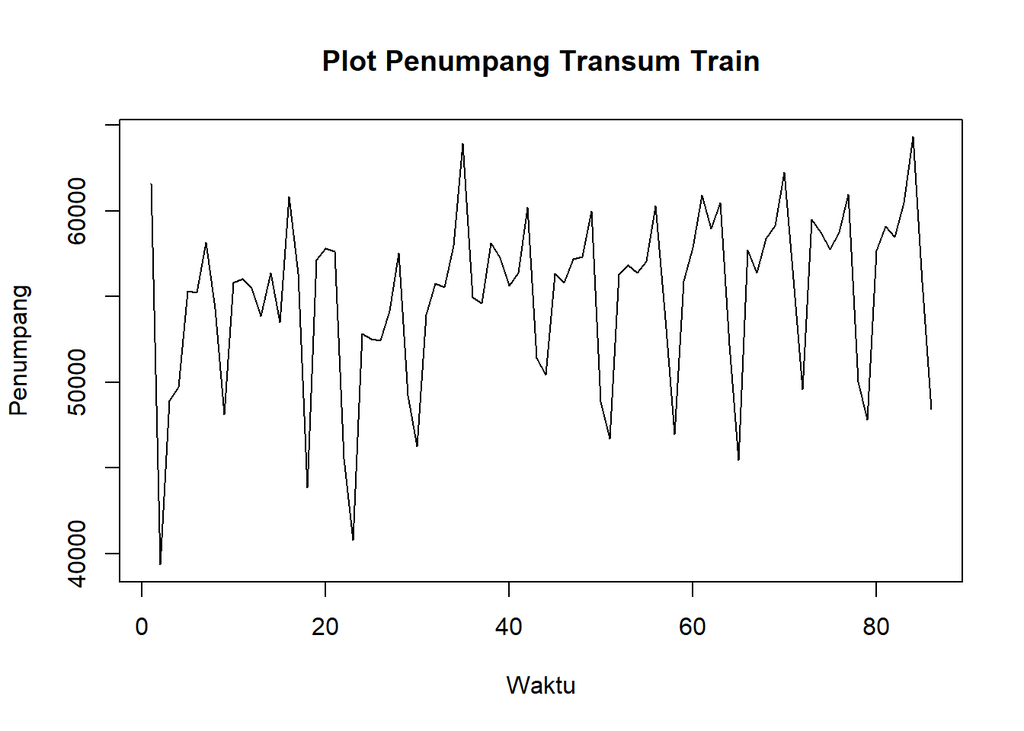

```r
datatrain <- data[1:86, ]
train.ts <- ts(datatrain$rail_monorail)
plot.ts(train.ts, lty = 1, xlab = "Waktu", ylab = "Penumpang", main = "Plot Penumpang Transum Train")
```

Berdasarkan plot data deret waktu pada data latih, terlihat bahwa data berfluktuasi di sekitar nilai tengah tertentu dengan kenaikan yang sangat landai. Terdapat pola penurunan tajam yang berulang kira-kira setiap 7 periode, sehingga data memiliki pola musiman (mingguan), bukan trend.

#### Plot Data Uji

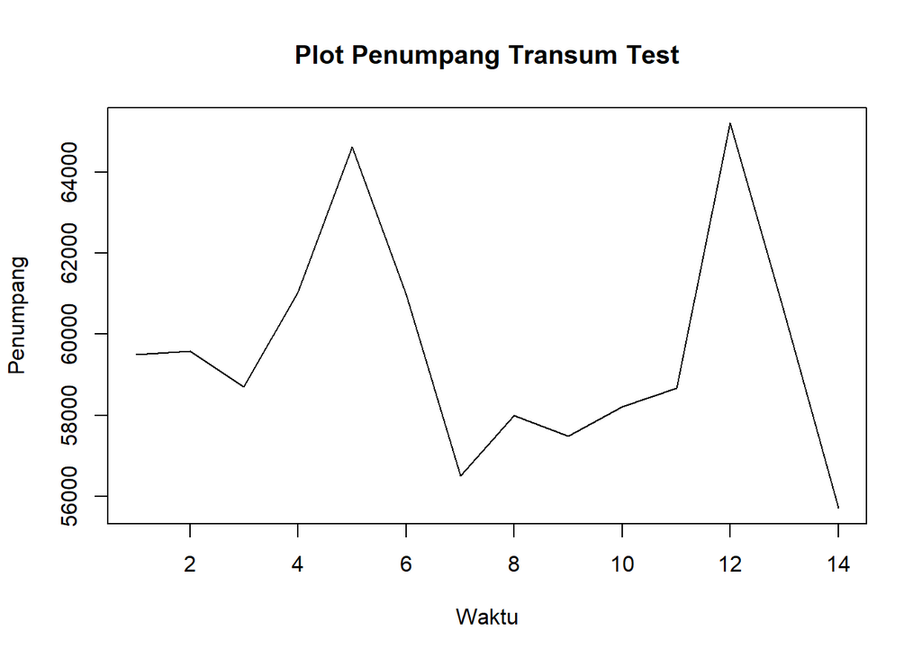

```r
datatest <- data[87:100, ]
test.ts <- ts(datatest$rail_monorail)
plot.ts(test.ts, lty = 1, xlab = "Waktu", ylab = "Penumpang", main = "Plot Penumpang Transum Test")
```

### Uji Stasioneritas Data

#### Plot ACF

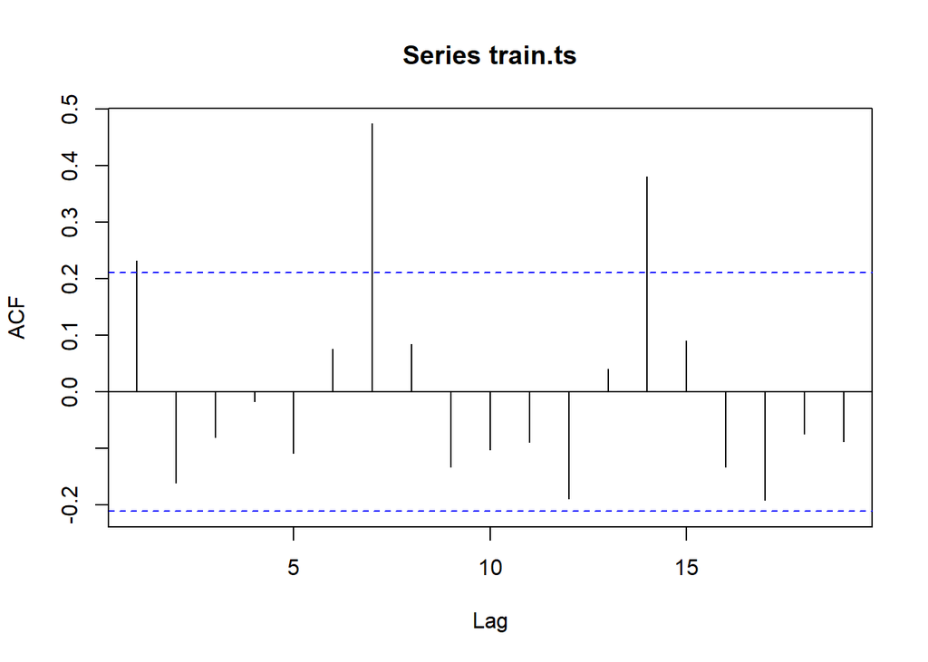

```r
acf(train.ts)
```

Berdasarkan plot ACF, terlihat bahwa plot ACF tidak meluruh perlahan (tails off slowly), tetapi berbentuk gelombang. Lag ke-7 (≈ 0,47) dan lag ke-14 (≈ 0,38) signifikan, sedangkan lag di antaranya tidak. Hal ini menunjukkan adanya pola musiman periode 7, bukan ketidakstasioneran dalam rataan.

#### Uji ADF

```r
adf_train <- tseries::adf.test(train.ts)
adf_train
```

```
##
##  Augmented Dickey-Fuller Test
##
## data:  train.ts
## Dickey-Fuller = -5.9041, Lag order = 4, p-value = 0.01
## alternative hypothesis: stationary
```

$H_0$ : Data tidak stasioner dalam rataan

$H_1$ : Data stasioner dalam rataan

Berdasarkan uji ADF tersebut, didapat *p-value* sebesar 0.01 (nilai yang dicetak R adalah batas bawah 0,01) yang lebih kecil dari taraf nyata 5% sehingga tolak $H_0$ dan menandakan bahwa data stasioner dalam rataan. Namun plot ACF memperlihatkan spike pada lag 7 dan 14 yang mengindikasikan adanya pola musiman mingguan, yang tidak dideteksi oleh uji ADF.

#### Plot Box-Cox

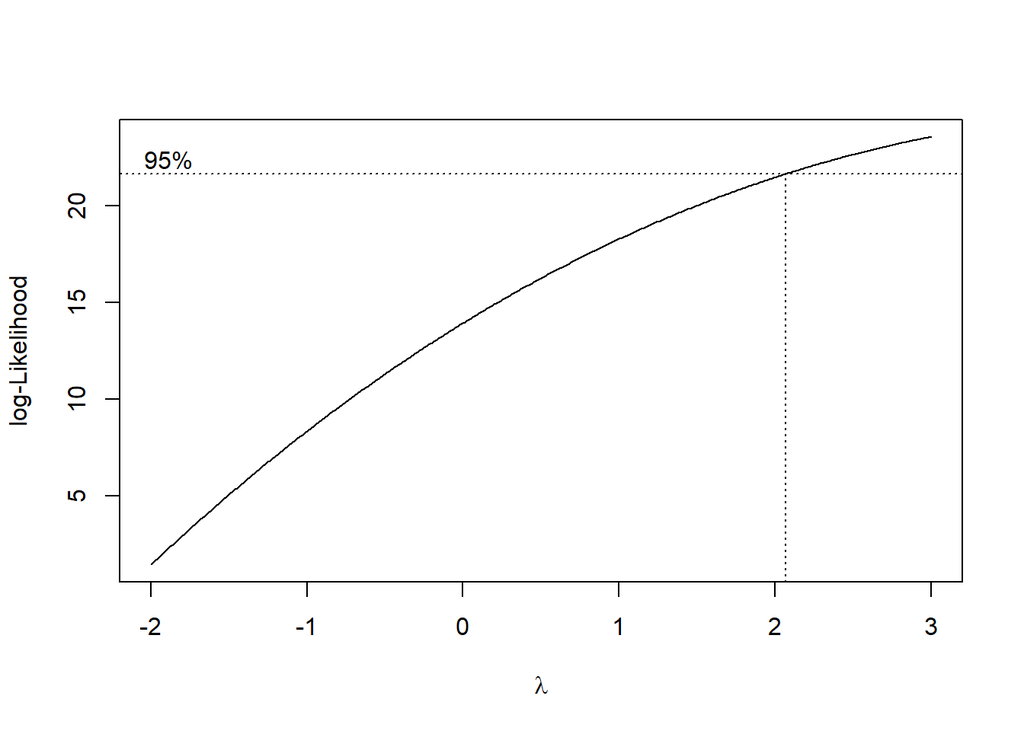

```r
index <- seq(1:86)

# Box-Cox
bc <- boxcox(train.ts ~ index, lambda = seq(-2, 3, by = 0.01))
```

```r
# Nilai lambda optimum (rounded)
lambda_opt <- bc$x[which.max(bc$y)]
lambda_opt
```

```
## [1] 3
```

```r
# Selang kepercayaan 95% untuk lambda
ci_lambda <- bc$x[bc$y > max(bc$y) - 0.5 * qchisq(0.95, df = 1)]

# Batas bawah dan batas atas
ci_lower <- min(ci_lambda)
ci_upper <- max(ci_lambda)

c(Batas_Bawah = ci_lower, Batas_Atas = ci_upper)
```

```
## Batas_Bawah  Batas_Atas
##        2.07        3.00
```

Berdasarkan plot Box-Cox, nilai lambda optimum sebesar 3 dengan selang kepercayaan 95% antara 2.07 dan 3. Nilai optimum berada di batas grid dan kurva log-likelihood terus naik, sehingga nilai lambda yang sebenarnya tidak dapat ditentukan dari grid ini. Karena plot data menunjukkan lebar fluktuasi yang relatif konstan, transformasi tidak dilakukan.

### Penanganan Pola Musiman Data

Karena data sudah stasioner dalam rataan, differencing tidak diperlukan. Pola musiman ditangani dengan memodelkan komponen musiman periode 7 langsung pada model SARIMA. Untuk itu data latih didefinisikan ulang dengan frekuensi 7.

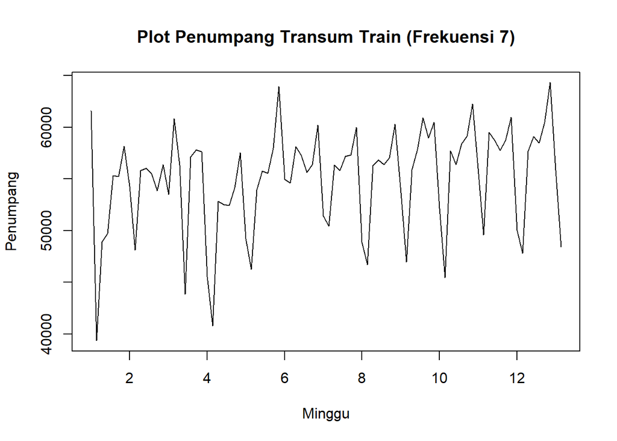

```r
train.ts7 <- ts(datatrain$rail_monorail, frequency = 7)
plot.ts(train.ts7, lty = 1, xlab = "Minggu", ylab = "Penumpang", main = "Plot Penumpang Transum Train (Frekuensi 7)")
```

Berdasarkan plot data deret waktu, terlihat bahwa data sudah stasioner dalam rataan, sehingga differencing tidak diperlukan. Pola naik-turun yang berulang setiap 7 periode merupakan pola musiman (efek hari dalam seminggu) yang akan dimodelkan dengan komponen musiman pada model SARIMA.

### Identifikasi Model

Setelah frekuensi data ditetapkan 7, sumbu-x pada ACF dan PACF berupa siklus: lag 1,0 sama dengan lag 7 dan lag 2,0 sama dengan lag 14.

#### Plot ACF

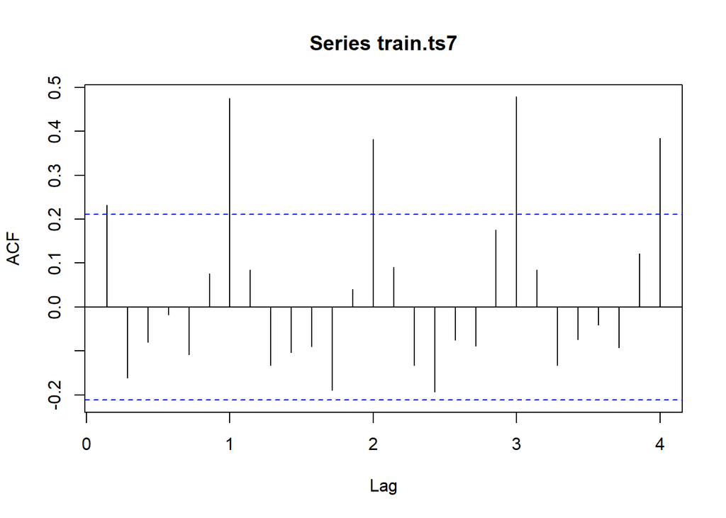

```r
acf(train.ts7, lag.max = 28)
```

Berdasarkan plot ACF, terlihat bahwa autokorelasi signifikan pada lag musiman ke-7, ke-14, ke-21, dan ke-28 (lag 1,0 sampai 4,0 pada sumbu-x) dan meluruh sangat lambat, sehingga menunjukkan pola musiman periode 7 yang kuat.

#### Plot PACF

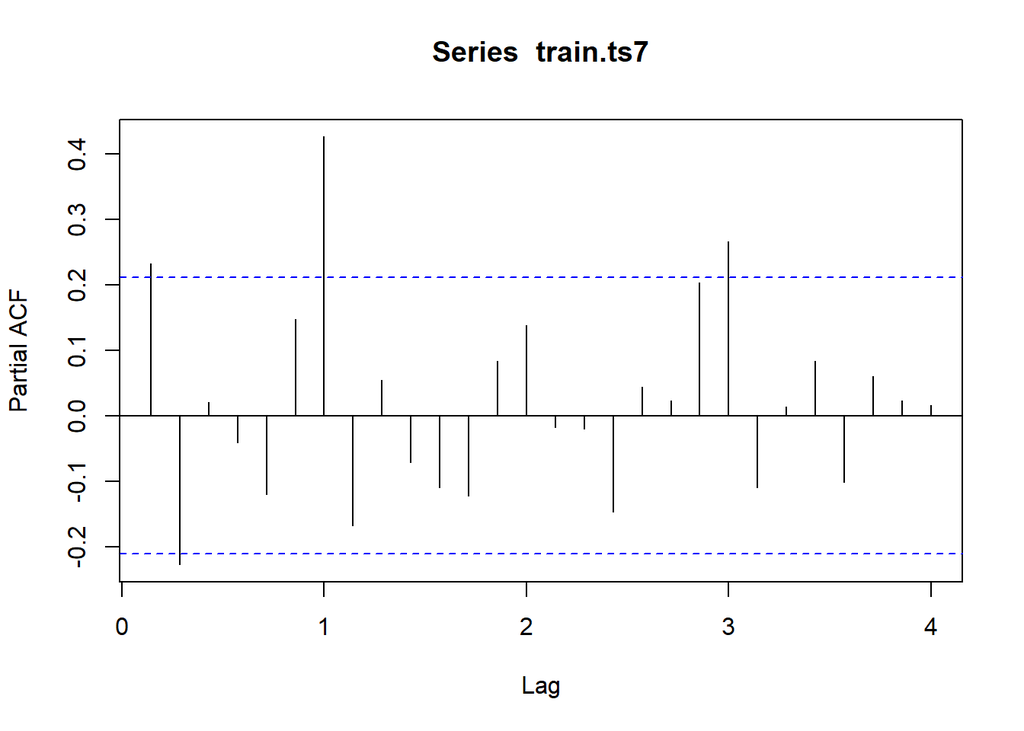

```r
pacf(train.ts7, lag.max = 28)
```

Berdasarkan plot PACF, terlihat bahwa PACF signifikan pada lag ke-7 dan ke-21, sehingga komponen musiman tidak cuts off setelah lag pertama dan dugaan awalnya adalah P = 1 dan Q = 1. Pada lag non-musiman, lag ke-1 dan ke-2 signifikan sehingga model tentatif yang dicoba adalah SARIMA(1,0,1)(1,0,0)[7], SARIMA(2,0,1)(1,0,0)[7], SARIMA(2,0,2)(1,0,0)[7], dan SARIMA(1,0,1)(1,0,1)[7].

### Pendugaan Parameter Model Tentatif

#### SARIMA(1,0,1)(1,0,0)[7]

```r
model1.sa <- Arima(train.ts7, order = c(1,0,1), seasonal = list(order = c(1,0,0), period = 7), method = "ML")
summary(model1.sa)
```

```
## Series: train.ts7
## ARIMA(1,0,1)(1,0,0)[7] with non-zero mean
##
## Coefficients:
##           ar1     ma1    sar1       mean
##       -0.2836  0.8197  0.6463  55171.588
## s.e.   0.1477  0.0818  0.0937   1391.709
##
## sigma^2 = 14145623:  log likelihood = -830.35
## AIC=1670.7   AICc=1671.45   BIC=1682.97
##
## Training set error measures:
##                    ME     RMSE      MAE        MPE     MAPE      MASE
## Training set 54.52625 3672.559 2580.332 -0.3801762 4.960153 0.8189785
##                     ACF1
## Training set -0.06479948
```

```r
lmtest::coeftest(model1.sa)
```

```
##
## z test of coefficients:
##
##              Estimate  Std. Error z value  Pr(>|z|)
## ar1       -2.8355e-01  1.4774e-01 -1.9192   0.05496 .
## ma1        8.1970e-01  8.1767e-02 10.0248 < 2.2e-16 ***
## sar1       6.4634e-01  9.3659e-02  6.9010 5.164e-12 ***
## intercept  5.5172e+04  1.3917e+03 39.6430 < 2.2e-16 ***
## ---
## Signif. codes:  0 '***' 0.001 '**' 0.01 '*' 0.05 '.' 0.1 ' ' 1
```

#### SARIMA(2,0,1)(1,0,0)[7]

```r
model2.sa <- Arima(train.ts7, order = c(2,0,1), seasonal = list(order = c(1,0,0), period = 7), method = "ML")
summary(model2.sa)
```

```
## Series: train.ts7
## ARIMA(2,0,1)(1,0,0)[7] with non-zero mean
##
## Coefficients:
##           ar1      ar2     ma1    sar1       mean
##       -0.2641  -0.0772  0.7930  0.6541  55166.863
## s.e.   0.1607   0.1344  0.1109  0.0939   1334.072
##
## sigma^2 = 14247278:  log likelihood = -830.18
## AIC=1672.37   AICc=1673.43   BIC=1687.1
##
## Training set error measures:
##                    ME     RMSE     MAE        MPE    MAPE      MASE        ACF1
## Training set 63.46971 3663.188 2596.97 -0.3559954 4.97778 0.8242594 -0.05535157
```

```r
lmtest::coeftest(model2.sa)
```

```
##
## z test of coefficients:
##
##              Estimate  Std. Error z value  Pr(>|z|)
## ar1       -2.6408e-01  1.6073e-01 -1.6430    0.1004
## ar2       -7.7179e-02  1.3445e-01 -0.5741    0.5659
## ma1        7.9304e-01  1.1086e-01  7.1538 8.442e-13 ***
## sar1       6.5407e-01  9.3851e-02  6.9692 3.186e-12 ***
## intercept  5.5167e+04  1.3341e+03 41.3522 < 2.2e-16 ***
## ---
## Signif. codes:  0 '***' 0.001 '**' 0.01 '*' 0.05 '.' 0.1 ' ' 1
```

#### SARIMA(2,0,2)(1,0,0)[7]

```r
model3.sa <- Arima(train.ts7, order = c(2,0,2), seasonal = list(order = c(1,0,0), period = 7), method = "ML")
summary(model3.sa)
```

```
## Series: train.ts7
## ARIMA(2,0,2)(1,0,0)[7] with non-zero mean
##
## Coefficients:
##          ar1     ar2     ma1      ma2    sar1       mean
##       0.0887  0.0044  0.4377  -0.2868  0.6509  55163.105
## s.e.  0.7229  0.2701  0.7118   0.5913  0.0942   1257.386
##
## sigma^2 = 14396110:  log likelihood = -830.08
## AIC=1674.16   AICc=1675.59   BIC=1691.34
##
## Training set error measures:
##                    ME     RMSE      MAE        MPE     MAPE     MASE
## Training set 65.28502 3659.471 2600.205 -0.3521166 4.978365 0.825286
##                     ACF1
## Training set -0.05099608
```

```r
lmtest::coeftest(model3.sa)
```

```
##
## z test of coefficients:
##
##              Estimate  Std. Error z value  Pr(>|z|)
## ar1        8.8680e-02  7.2291e-01  0.1227    0.9024
## ar2        4.3735e-03  2.7011e-01  0.0162    0.9871
## ma1        4.3773e-01  7.1180e-01  0.6150    0.5386
## ma2       -2.8677e-01  5.9134e-01 -0.4850    0.6277
## sar1       6.5094e-01  9.4229e-02  6.9081 4.913e-12 ***
## intercept  5.5163e+04  1.2574e+03 43.8713 < 2.2e-16 ***
## ---
## Signif. codes:  0 '***' 0.001 '**' 0.01 '*' 0.05 '.' 0.1 ' ' 1
```

#### SARIMA(1,0,1)(1,0,1)[7]

```r
model4.sa <- Arima(train.ts7, order = c(1,0,1), seasonal = list(order = c(1,0,1), period = 7), method = "ML")
summary(model4.sa)
```

```
## Series: train.ts7
## ARIMA(1,0,1)(1,0,1)[7] with non-zero mean
##
## Coefficients:
##           ar1     ma1    sar1     sma1       mean
##       -0.3542  0.8608  0.9704  -0.7344  55224.440
## s.e.   0.1426  0.0697  0.0302   0.1339   1828.453
##
## sigma^2 = 11784101:  log likelihood = -823.96
## AIC=1659.92   AICc=1660.98   BIC=1674.65
##
## Training set error measures:
##                    ME     RMSE      MAE       MPE     MAPE      MASE
## Training set 334.0038 3331.513 2448.776 0.2141449 4.632415 0.7772235
##                     ACF1
## Training set -0.07872949
```

```r
lmtest::coeftest(model4.sa)
```

```
##
## z test of coefficients:
##
##              Estimate  Std. Error z value  Pr(>|z|)
## ar1       -3.5418e-01  1.4259e-01 -2.4839     0.013 *
## ma1        8.6078e-01  6.9707e-02 12.3485 < 2.2e-16 ***
## sar1       9.7040e-01  3.0247e-02 32.0826 < 2.2e-16 ***
## sma1      -7.3441e-01  1.3386e-01 -5.4865 4.099e-08 ***
## intercept  5.5224e+04  1.8285e+03 30.2028 < 2.2e-16 ***
## ---
## Signif. codes:  0 '***' 0.001 '**' 0.01 '*' 0.05 '.' 0.1 ' ' 1
```

#### Ringkasan AIC

```r
model_tentatif <- data.frame(
  Model = c("SARIMA(1,0,1)(1,0,0)[7]", "SARIMA(2,0,1)(1,0,0)[7]",
            "SARIMA(2,0,2)(1,0,0)[7]", "SARIMA(1,0,1)(1,0,1)[7]"),
  AIC = c(AIC(model1.sa), AIC(model2.sa), AIC(model3.sa), AIC(model4.sa)),
  BIC = c(BIC(model1.sa), BIC(model2.sa), BIC(model3.sa), BIC(model4.sa))
)
model_tentatif
```

```
##                     Model      AIC      BIC
## 1 SARIMA(1,0,1)(1,0,0)[7] 1670.697 1682.969
## 2 SARIMA(2,0,1)(1,0,0)[7] 1672.370 1687.096
## 3 SARIMA(2,0,2)(1,0,0)[7] 1674.156 1691.336
## 4 SARIMA(1,0,1)(1,0,1)[7] 1659.920 1674.646
```

Berdasarkan pendugaan parameter di atas, model SARIMA(1,0,1)(1,0,1)[7] memiliki AIC (1659,92) dan BIC (1674,65) terkecil dengan seluruh parameter signifikan (ar1 p = 0,013; ma1, sar1, dan sma1 p < 0,001), sehingga model yang dipilih adalah SARIMA(1,0,1)(1,0,1)[7]. Perlu dicatat bahwa koefisien sar1 (0,97) mendekati 1, yang konsisten dengan ACF yang menunjukkan lag musiman 7, 14, 21, dan 28 sama-sama signifikan dan meluruh sangat lambat.

### Analisis Sisaan

Model terbaik hasil identifikasi kemudian dicek asumsi sisaannya. Sisaan model SARIMA harus memenuhi asumsi normalitas, kebebasan sisaan, dan kehomogenan ragam. Diagnostik model dilakukan secara eksplorasi dan uji formal.

#### Eksplorasi Sisaan

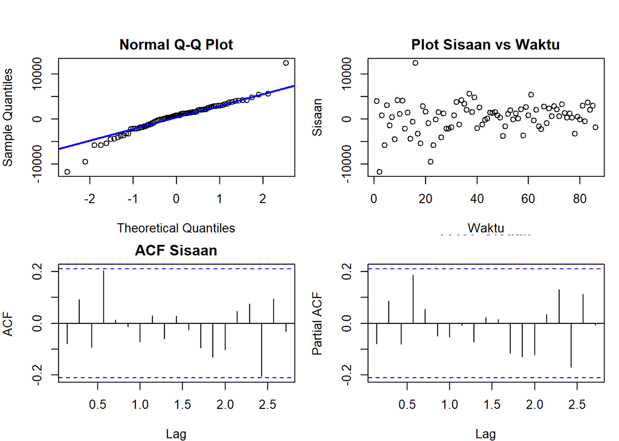

```r
model_terbaik <- model4.sa   # SARIMA(1,0,1)(1,0,1)[7]
sisaan.sa <- residuals(model_terbaik)

par(mfrow = c(2,2),
    mar = c(4,4,2,1),
    oma = c(0,0,2,0))

# Q-Q Plot
qqnorm(sisaan.sa, main = "Normal Q-Q Plot")
qqline(sisaan.sa, col = "blue", lwd = 2)

# Plot Sisaan vs Waktu
plot(as.numeric(sisaan.sa), type = "p",
     main = "Plot Sisaan vs Waktu",
     xlab = "Waktu", ylab = "Sisaan")

# ACF
acf(sisaan.sa, main = "ACF Sisaan")

# PACF
pacf(sisaan.sa, main = "PACF Sisaan")
```

```r
par(mfrow = c(1,1))
```

- Berdasarkan Normal Q-Q Plot, secara eksploratif terlihat bahwa sebagian besar sisaan mengikuti garis acuan, kecuali beberapa titik pada bagian ujung bawah (ekor kiri) dan satu titik pada ujung atas yang menyimpang dari garis acuan, sehingga sisaan cenderung memiliki ekor yang lebih berat daripada sebaran normal.
- Berdasarkan Plot Sisaan vs Waktu, fluktuasi sisaan tampak tersebar di sekitar nilai nol seiring dengan bertambahnya waktu.
- Berdasarkan plot ACF dan PACF sisaan, terlihat bahwa spike pada lag musiman ke-7 dan ke-14 yang sebelumnya muncul sudah hilang, dan hampir seluruh nilai autokorelasi berada di dalam batas signifikansi (garis putus-putus biru), kecuali dua lag yang hanya menyentuh batas (lag ke-4 dan ke-17), sehingga secara visual sisaan dapat dianggap saling bebas. Kondisi ini akan diuji lebih lanjut dengan uji formal.

#### Uji Formal

```r
#1) Sisaan Menyebar Normal
ks_res <- ks.test(sisaan.sa, "pnorm", mean = mean(sisaan.sa), sd = sd(sisaan.sa))
ks_res
```

```
##
##  Exact one-sample Kolmogorov-Smirnov test
##
## data:  sisaan.sa
## D = 0.10237, p-value = 0.307
## alternative hypothesis: two-sided
```

```r
sw_res <- shapiro.test(sisaan.sa)
sw_res
```

```
##
##  Shapiro-Wilk normality test
##
## data:  sisaan.sa
## W = 0.93844, p-value = 0.0004808
```

Selain dengan eksplorasi, asumsi tersebut dapat diuji menggunakan uji formal. Pada tahapan ini uji formal yang digunakan untuk normalitas adalah uji Kolmogorov-Smirnov (KS) dan Shapiro-Wilk. Hipotesis pada kedua uji adalah sebagai berikut.

$H_0$ : Sisaan menyebar normal

$H_1$ : Sisaan tidak menyebar normal

```r
#2) Sisaan saling bebas/tidak ada autokorelasi
lb_res <- Box.test(sisaan.sa, lag = 20, type = "Ljung", fitdf = 4)
lb_res
```

```
##
##  Box-Ljung test
##
## data:  sisaan.sa
## X-squared = 20.432, df = 16, p-value = 0.2014
```

Selanjutnya akan dilakukan uji formal untuk kebebasan sisaan menggunakan uji Ljung-Box pada 20 lag pertama. Hipotesis yang digunakan adalah sebagai berikut.

$H_0$ : Sisaan saling bebas

$H_1$ : Sisaan tidak saling bebas

Berdasarkan uji Ljung-Box tersebut, didapat p-value sebesar $0.2014$ yang lebih besar dari taraf nyata 5% sehingga gagal tolak $H_0$ dan menandakan bahwa sisaan saling bebas. Hal ini sesuai dengan hasil eksplorasi pada plot ACF dan PACF sisaan yang sebagian besar berada di dalam batas signifikansi.

```r
#3) Sisaan homogen
lb_sq <- Box.test(sisaan.sa^2, lag = 20, type = "Ljung")
lb_sq
```

```
##
##  Box-Ljung test
##
## data:  sisaan.sa^2
## X-squared = 29.893, df = 20, p-value = 0.07161
```

Hipotesis yang digunakan untuk uji kehomogenan ragam adalah sebagai berikut.

$H_0$ : Ragam sisaan homogen

$H_1$ : Ragam sisaan tidak homogen

Berdasarkan uji Ljung-Box terhadap sisaan kuadrat tersebut, didapat p-value sebesar $0.0716$ yang lebih besar dari taraf nyata 5% sehingga gagal tolak $H_0$ dan menandakan bahwa ragam sisaan homogen, namun nilai ini dekat dengan batas 5% sehingga kehomogenan ragam hanya terpenuhi secara terbatas.

```r
#4) Nilai tengah sisaan sama dengan nol
tt_res <- t.test(sisaan.sa, mu = 0, conf.level = 0.95)
tt_res
```

```
##
##  One Sample t-test
##
## data:  sisaan.sa
## t = 0.92899, df = 85, p-value = 0.3555
## alternative hypothesis: true mean is not equal to 0
## 95 percent confidence interval:
##  -380.8436 1048.8511
## sample estimates:
## mean of x
##  334.0038
```

Terakhir, dengan uji-t, akan dicek apakah nilai tengah sisaan sama dengan nol. Hipotesis yang diujikan sebagai berikut.

$H_0$ : nilai tengah sisaan sama dengan 0

$H_1$ : nilai tengah sisaan tidak sama dengan 0

Berdasarkan uji-t tersebut, didapat *p-value* sebesar 0.3555 yang lebih besar dari taraf nyata 5% sehingga gagal tolak $H_0$ dan menandakan bahwa nilai tengah sisaan sama dengan nol. Hal ini sesuai dengan hasil eksplorasi pada plot sisaan yang menyebar di sekitar nol.

### Overfitting

```r
model5.sa <- Arima(train.ts7, order = c(2,0,1), seasonal = list(order = c(1,0,1), period = 7), method = "ML")
summary(model5.sa)
```

```
## Series: train.ts7
## ARIMA(2,0,1)(1,0,1)[7] with non-zero mean
##
## Coefficients:
##           ar1      ar2     ma1    sar1     sma1       mean
##       -0.3542  -0.0007  0.8606  0.9703  -0.7341  55225.485
## s.e.   0.1419   0.1290  0.0734  0.0332   0.1430   1827.486
##
## sigma^2 = 11931865:  log likelihood = -823.96
## AIC=1661.92   AICc=1663.36   BIC=1679.1
##
## Training set error measures:
##                    ME     RMSE      MAE       MPE    MAPE      MASE        ACF1
## Training set 333.8964 3331.578 2448.866 0.2139336 4.63256 0.7772523 -0.07854872
```

```r
lmtest::coeftest(model5.sa)
```

```
##
## z test of coefficients:
##
##              Estimate  Std. Error z value  Pr(>|z|)
## ar1       -3.5416e-01  1.4193e-01 -2.4954   0.01258 *
## ar2       -7.2408e-04  1.2902e-01 -0.0056   0.99552
## ma1        8.6063e-01  7.3444e-02 11.7182 < 2.2e-16 ***
## sar1       9.7034e-01  3.3171e-02 29.2524 < 2.2e-16 ***
## sma1      -7.3414e-01  1.4296e-01 -5.1352 2.819e-07 ***
## intercept  5.5225e+04  1.8275e+03 30.2194 < 2.2e-16 ***
## ---
## Signif. codes:  0 '***' 0.001 '**' 0.01 '*' 0.05 '.' 0.1 ' ' 1
```

```r
model6.sa <- Arima(train.ts7, order = c(1,0,2), seasonal = list(order = c(1,0,1), period = 7), method = "ML")
summary(model6.sa)
```

```
## Series: train.ts7
## ARIMA(1,0,2)(1,0,1)[7] with non-zero mean
##
## Coefficients:
##           ar1     ma1      ma2    sar1    sma1       mean
##       -0.3493  0.8555  -0.0042  0.9703  -0.733  55235.964
## s.e.   0.5053  0.5204   0.4117  0.0315   0.142   1831.427
##
## sigma^2 = 11929283:  log likelihood = -823.96
## AIC=1661.92   AICc=1663.36   BIC=1679.1
##
## Training set error measures:
##                    ME     RMSE      MAE       MPE     MAPE      MASE
## Training set 332.6673 3331.217 2448.261 0.2120708 4.631425 0.7770602
##                     ACF1
## Training set -0.07785472
```

```r
lmtest::coeftest(model6.sa)
```

```
##
## z test of coefficients:
##
##              Estimate  Std. Error z value  Pr(>|z|)
## ar1       -3.4932e-01  5.0531e-01 -0.6913    0.4894
## ma1        8.5546e-01  5.2035e-01  1.6440    0.1002
## ma2       -4.1534e-03  4.1172e-01 -0.0101    0.9920
## sar1       9.7029e-01  3.1535e-02 30.7686 < 2.2e-16 ***
## sma1      -7.3297e-01  1.4196e-01 -5.1632 2.427e-07 ***
## intercept  5.5236e+04  1.8314e+03 30.1601 < 2.2e-16 ***
## ---
## Signif. codes:  0 '***' 0.001 '**' 0.01 '*' 0.05 '.' 0.1 ' ' 1
```

Tahapan selanjutnya adalah overfitting yang dilakukan dengan menaikkan orde AR(p) dan MA(q) dari model SARIMA(1,0,1)(1,0,1)[7]. Kandidat model overfitting adalah SARIMA(2,0,1)(1,0,1)[7] dan SARIMA(1,0,2)(1,0,1)[7]. Berdasarkan hasil pendugaan, AIC kedua model sama-sama 1661,92, lebih besar dari AIC model SARIMA(1,0,1)(1,0,1)[7] (1659,92). Parameter tambahan (ar2 dengan p = 0,9955 dan ma2 dengan p = 0,9920) tidak signifikan, bahkan pada model SARIMA(1,0,2)(1,0,1)[7] parameter ar1 dan ma1 ikut menjadi tidak signifikan. Dengan demikian, model hasil overfitting tidak lebih baik sehingga model terbaik yang dipilih tetap SARIMA(1,0,1)(1,0,1)[7] dan dilanjutkan dengan peramalan.

### Model Terbaik : SARIMA(1,0,1)(1,0,1)[7]

```r
summary(model_terbaik)
```

```
## Series: train.ts7
## ARIMA(1,0,1)(1,0,1)[7] with non-zero mean
##
## Coefficients:
##           ar1     ma1    sar1     sma1       mean
##       -0.3542  0.8608  0.9704  -0.7344  55224.440
## s.e.   0.1426  0.0697  0.0302   0.1339   1828.453
##
## sigma^2 = 11784101:  log likelihood = -823.96
## AIC=1659.92   AICc=1660.98   BIC=1674.65
##
## Training set error measures:
##                    ME     RMSE      MAE       MPE     MAPE      MASE
## Training set 334.0038 3331.513 2448.776 0.2141449 4.632415 0.7772235
##                     ACF1
## Training set -0.07872949
```

```r
lmtest::coeftest(model_terbaik)
```

```
##
## z test of coefficients:
##
##              Estimate  Std. Error z value  Pr(>|z|)
## ar1       -3.5418e-01  1.4259e-01 -2.4839     0.013 *
## ma1        8.6078e-01  6.9707e-02 12.3485 < 2.2e-16 ***
## sar1       9.7040e-01  3.0247e-02 32.0826 < 2.2e-16 ***
## sma1      -7.3441e-01  1.3386e-01 -5.4865 4.099e-08 ***
## intercept  5.5224e+04  1.8285e+03 30.2028 < 2.2e-16 ***
## ---
## Signif. codes:  0 '***' 0.001 '**' 0.01 '*' 0.05 '.' 0.1 ' ' 1
```

### Peramalan

Peramalan dilakukan menggunakan fungsi `forecast()`. Peramalan berikut ini dilakukan untuk 14 periode ke depan, sesuai banyaknya data uji.

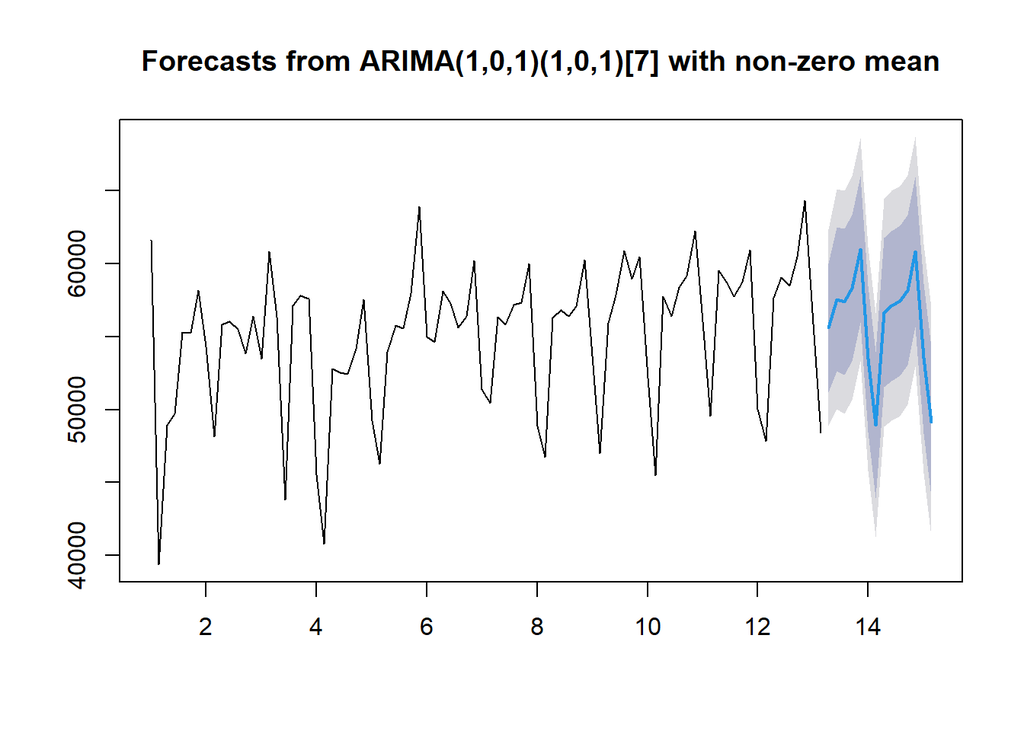

```r
# ---FORECAST---
ramalan.sa <- forecast::forecast(model_terbaik, h = length(test.ts))
plot(ramalan.sa)
```

```r
hasil <- as.numeric(ramalan.sa$mean)

# Bandingkan aktual vs forecast
perbandingan.sa <- cbind(
  Aktual   = as.numeric(test.ts),
  Forecast = hasil
)
print(perbandingan.sa)
```

```
##       Aktual Forecast
##  [1,]  59507 55601.13
##  [2,]  59580 57562.96
##  [3,]  58705 57375.73
##  [4,]  61035 58324.99
##  [5,]  64625 60977.27
##  [6,]  60964 53466.53
##  [7,]  56509 48932.65
##  [8,]  57998 56637.99
##  [9,]  57483 57122.54
## [10,]  58217 57443.51
## [11,]  58664 58186.64
## [12,]  65202 60823.46
## [13,]  60526 53512.73
## [14,]  55712 49120.98
```

```r
# Hitung akurasi
akurasi_test <- accuracy(hasil, as.numeric(test.ts))
akurasi_test
```

```
##                ME     RMSE      MAE      MPE     MAPE
## Test set 3545.563 4391.219 3545.563 5.946497 5.946497
```

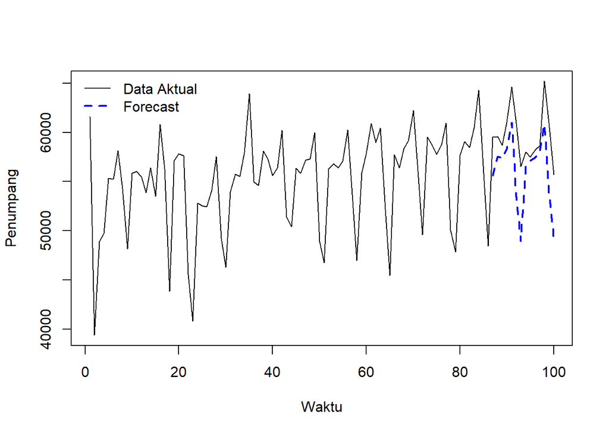

```r
# Plot data aktual dan forecast
ts.plot(data.ts, col = "black", lty = 1,
        xlab = "Waktu", ylab = "Penumpang")

# Garis forecast
lines(87:100, hasil, col = "blue", lty = 2, lwd = 2)
legend("topleft",
       legend = c("Data Aktual", "Forecast"),
       col = c("black", "blue"),
       lty = c(1,2), lwd = c(1,2), bty = "n")
```

Berdasarkan plot hasil peramalan, terlihat bahwa nilai ramalan mengikuti pola naik-turun mingguan pada data uji, tetapi cenderung lebih rendah dari data aktual (ME = 3545.6, MAPE = 5.95%). Hal ini menunjukkan bahwa model sudah menangkap pola musiman, namun belum menangkap kenaikan level data pada periode uji. Nilai RMSE sebesar 4391.2 dan MAPE sebesar 5.95% menunjukkan bahwa model memiliki tingkat kesalahan peramalan yang cukup kecil.